# HW 4

Emily Branch

2024-11-01

```r
options(scipen=10000000)

library(tidyverse)
library(kableExtra)
library(caret)
library(knitr)
library(pscl)
library(plotROC)
library(pROC)
library(lubridate)
library(caret)
library(scales)
library(ggplot2)
library(gridExtra)
library(formattable)

palette3 = c("#736EF5", "#C2F569", "#A4C4F4", "orange")
```

```r
housingsubs <- read.csv("https://raw.githubusercontent.com/urbanSpatial/Public-Policy-Analytics-Landing/refs/heads/master/DATA/Chapter6/housingSubsidy.csv")
```

## Purpose

The Department of Housing and Community Development (HCD) in Emil City has a home repair tax credit program that provides eligible residents with a $5,000 tax credit, but the tax credit is under-utilized by city residents. Staff at the HCD have reason to believe that targeted outreach will improve the credit acceptance rate. In order to identify eligible residents that are likely to participate, a logistic regression will be used to classify past customer-level data and predict whether a customer is likely to accept the tax credit or not.

The model will be created using all of the available data along with a few engineered features to improve accuracy. This classification algorithm aims to predict a binary outcome, accepting the tax credit or not, and as such the threshold for what is considered a positive outcome (i.e. accepting the tax credit) becomes important. This threshold will be selected to maximize the potential revenue of the program based on a cost benefit analysis.

In summary, the process will be as follows:

1. Exploratory Data Analysis: Examining the consumer data.
2. Logistic Regression: Creating and tweaking logistic regressions.
3. Evaluating Logistic Regression: Assessing the accuracy of the logistic regressions.
4. Maximizing Revenues: Determining the optimal prediction threshold for program revenues.

## Analysis

### Exploratory Data Analysis

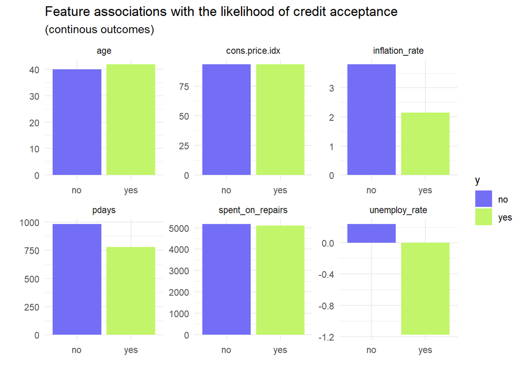

```r
housingsubs %>%
  dplyr::select(y,age, unemploy_rate, spent_on_repairs, inflation_rate, cons.price.idx, pdays) %>%
  gather(Variable, value, -y) %>%
    ggplot(aes(y, value, fill=y)) +
      geom_bar(position = "dodge", stat = "summary", fun = "mean") +
      facet_wrap(~Variable, scales = "free") +
      scale_fill_manual(values = palette3) +
      labs(x="", y="",
           title = "Feature associations with the likelihood of credit acceptance",
           subtitle = "(continous outcomes)") +
      theme(legend.position = "none") +
  theme_minimal()
```

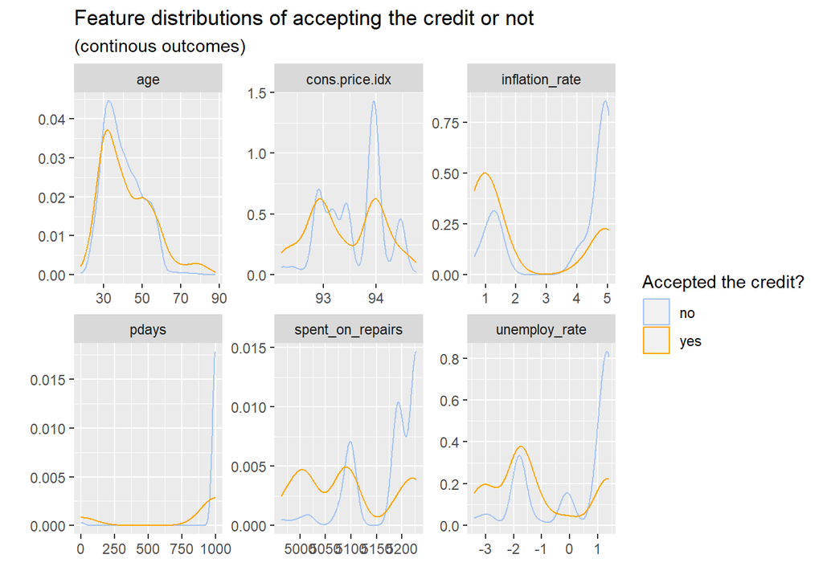

```r
housingsubs %>%
    dplyr::select(y,age, unemploy_rate, spent_on_repairs, inflation_rate, cons.price.idx, pdays) %>%
    gather(Variable, value, -y) %>%
    ggplot() +
    geom_density(aes(value, color=y), fill = "transparent") +
    facet_wrap(~Variable, scales = "free") +
    scale_color_manual(values = palette3[3:4]) +
    labs(title = "Feature distributions of accepting the credit or not",
         subtitle = "(continous outcomes)",
         color = "Accepted the credit?", x = "", y = "")
```

Examining the continuous variables by whether consumers accepted the tax credit, it is evident that some factors differ noticeably between these outcomes. Unemployment rate and inflation rate both show sizable differences in average values across the dependent variable. Oppositely, the money spent on repairs and age does not appear to differ significantly across outcomes. Therefore, unemployment and inflation rate are likely be useful for the logistic regression while age is less likely to be.

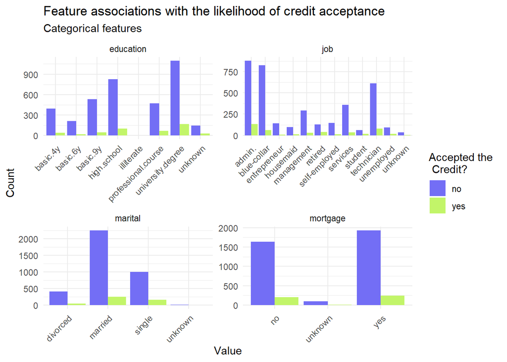

```r
housingsubs %>%
    dplyr::select(y, job, marital, education, mortgage) %>%
    gather(Variable, value, -y) %>%
    count(Variable, value, y) %>%
      ggplot(., aes(value, n, fill = y)) +
        geom_bar(position = "dodge", stat="identity") +
        facet_wrap(~Variable, scales="free") +
        scale_fill_manual(values = palette3) +
        labs(y="Count", x= "Value",
             title = "Feature associations with the likelihood of credit acceptance",
             subtitle = "Categorical features", fill = "Accepted the \n Credit?") +
  theme_minimal() +
        theme(axis.text.x = element_text(angle = 45, hjust = 1))
```

Examining the categorical variables through the same lens as the continous variables above is not as useful because there are simply so many more residents who do not end up accepting the tax credit. However, some categories have higher rates of participation, including residents whose job is administrative or residents with a university degree.

### Logistic Regression

```r
set.seed(4545)

trainIndex <- createDataPartition(housingsubs$y, p = .65,
                                  list = FALSE,
                                  times = 1)
housingsubsTrain <- housingsubs[ trainIndex,]
housingsubsTest  <- housingsubs[-trainIndex,]
```

```r
housingsubs_extra <- housingsubs %>%
  mutate(
    no_inc = if_else((job == "unemployed" | job == "retired" | job == "student"), TRUE, FALSE),
   uni = if_else((education == "university.degree" | education == "professional.course"), TRUE, FALSE),
    pdays_cat = case_when(
      pdays < 3 ~ "0-2",
      pdays <5 ~ "3-4",
      pdays < 10 ~ "5-9",
      pdays < 999 ~ "10+",
      pdays == 999 ~ "never"
    ),
  )
```

```r
set.seed(1234)

trainIndex <- createDataPartition(housingsubs_extra$y, p = .65,
                                  list = FALSE,
                                  times = 1)
housingsubs_eTrain <- housingsubs_extra[ trainIndex,]
housingsubs_eTest  <- housingsubs_extra[-trainIndex,]


housingsubsModel <- glm(y_numeric ~ .,
                  data=housingsubs_eTrain %>%
                    dplyr::select(-y, -taxLien, -uni, -pdays_cat, -no_inc),
                  family="binomial" (link="logit"))

housingsubsModel_extra <- glm(y_numeric ~ .,
                  data=housingsubs_eTrain %>% dplyr::select(-y, -education),
                  family="binomial" (link="logit"))
```

```r
Unfiltered_Model <- (pR2(housingsubsModel))
Engineered_Model <- pR2(housingsubsModel_extra)
```

```r
kable(cbind(Unfiltered_Model, Engineered_Model), caption = "Comparing Unfiltered Vs. Engineered Model") %>% kable_styling("striped")
```

Comparing Unfiltered Vs. Engineered Model

|  | Unfiltered_Model | Engineered_Model |
| --- | --- | --- |
| llh | -717.2626777 | -715.1457468 |
| llhNull | -926.8710680 | -926.8710680 |
| G2 | 419.2167806 | 423.4506424 |
| McFadden | 0.2261462 | 0.2284302 |
| r2ML | 0.1448536 | 0.1462040 |
| r2CU | 0.2900537 | 0.2927577 |

The engineered model has a marginally better McFadden Pseudo-R-squared value.

```r
kable(broom::glance(housingsubsModel), caption = "Unfiltered Model Summary") %>% kable_styling()
```

Unfiltered Model Summary

| null.deviance | df.null | logLik | AIC | BIC | deviance | df.residual | nobs |
| --- | --- | --- | --- | --- | --- | --- | --- |
| 1853.742 | 2678 | -717.2627 | 1534.525 | 1829.185 | 1434.525 | 2629 | 2679 |

```r
kable(broom::tidy(housingsubsModel), caption = "Unfiltered Model Summary") %>% kable_styling("striped")%>%
  scroll_box(width = "100%", height = "400px")
```

Unfiltered Model Summary

| term | estimate | std.error | statistic | p.value |
| --- | --- | --- | --- | --- |
| (Intercept) | -321.2152996 | 136.5710151 | -2.3520020 | 0.0186727 |
| X | 0.0000370 | 0.0000607 | 0.6096622 | 0.5420856 |
| age | 0.0158464 | 0.0085404 | 1.8554633 | 0.0635301 |
| jobblue-collar | -0.3386943 | 0.2762235 | -1.2261605 | 0.2201383 |
| jobentrepreneur | -0.6106529 | 0.4718279 | -1.2942282 | 0.1955866 |
| jobhousemaid | -0.2829373 | 0.4932198 | -0.5736536 | 0.5662022 |
| jobmanagement | -0.5316007 | 0.3026933 | -1.7562355 | 0.0790482 |
| jobretired | -0.2172817 | 0.3742596 | -0.5805641 | 0.5615343 |
| jobself-employed | -0.5961817 | 0.4472449 | -1.3330096 | 0.1825287 |
| jobservices | -0.2267567 | 0.2975139 | -0.7621716 | 0.4459576 |
| jobstudent | -0.2476816 | 0.4700276 | -0.5269512 | 0.5982275 |
| jobtechnician | 0.0145155 | 0.2339129 | 0.0620553 | 0.9505188 |
| jobunemployed | -0.3431362 | 0.4399317 | -0.7799759 | 0.4354050 |
| jobunknown | -0.7405078 | 0.8500002 | -0.8711855 | 0.3836529 |
| maritalmarried | -0.0267755 | 0.2300305 | -0.1163999 | 0.9073356 |
| maritalsingle | -0.0062365 | 0.2701515 | -0.0230854 | 0.9815822 |
| maritalunknown | 0.2134376 | 1.1512588 | 0.1853950 | 0.8529192 |
| educationbasic.6y | 0.1431937 | 0.4306871 | 0.3324774 | 0.7395288 |
| educationbasic.9y | 0.3611103 | 0.3256247 | 1.1089771 | 0.2674401 |
| educationhigh.school | 0.1489789 | 0.3223664 | 0.4621415 | 0.6439798 |
| educationprofessional.course | 0.0564831 | 0.3576001 | 0.1579505 | 0.8744958 |
| educationuniversity.degree | 0.2177881 | 0.3223584 | 0.6756088 | 0.4992891 |
| educationunknown | 0.1314798 | 0.4305668 | 0.3053644 | 0.7600886 |
| mortgageunknown | -0.7141913 | 0.6200658 | -1.1517991 | 0.2494036 |
| mortgageyes | -0.0462220 | 0.1465065 | -0.3154947 | 0.7523861 |
| taxbill_in_phlyes | -0.1585226 | 0.1885989 | -0.8405275 | 0.4006127 |
| contacttelephone | -1.5211520 | 0.3440612 | -4.4211667 | 0.0000098 |
| monthaug | 0.2214409 | 0.4475941 | 0.4947360 | 0.6207865 |
| monthdec | 1.0829411 | 0.7350038 | 1.4733817 | 0.1406481 |
| monthjul | -0.3500172 | 0.3905169 | -0.8962922 | 0.3700967 |
| monthjun | -0.4754925 | 0.4712913 | -1.0089144 | 0.3130157 |
| monthmar | 2.1547793 | 0.5751163 | 3.7466847 | 0.0001792 |
| monthmay | 0.0958769 | 0.3163990 | 0.3030252 | 0.7618707 |
| monthnov | -0.3545465 | 0.4477905 | -0.7917687 | 0.4284956 |
| monthoct | 0.4495208 | 0.5606927 | 0.8017240 | 0.4227126 |
| monthsep | 0.3078691 | 0.6526085 | 0.4717516 | 0.6371041 |
| day_of_weekmon | -0.1666738 | 0.2224409 | -0.7492948 | 0.4536795 |
| day_of_weekthu | -0.4311765 | 0.2324291 | -1.8550883 | 0.0635836 |
| day_of_weektue | -0.1658463 | 0.2279630 | -0.7275140 | 0.4669111 |
| day_of_weekwed | 0.0406690 | 0.2281095 | 0.1782872 | 0.8584974 |
| campaign | -0.0915050 | 0.0447457 | -2.0449987 | 0.0408550 |
| pdays | -0.0003975 | 0.0007992 | -0.4973297 | 0.6189566 |
| previous | 0.1722022 | 0.2086160 | 0.8254509 | 0.4091156 |
| poutcomenonexistent | 0.7767231 | 0.3431873 | 2.2632628 | 0.0236195 |
| poutcomesuccess | 1.4111277 | 0.7992919 | 1.7654724 | 0.0774844 |
| unemploy_rate | -1.2747355 | 0.5061187 | -2.5186491 | 0.0117806 |
| cons.price.idx | 2.6587616 | 0.9024348 | 2.9462091 | 0.0032169 |
| cons.conf.idx | 0.0855159 | 0.0298784 | 2.8621351 | 0.0042080 |
| inflation_rate | -0.3082229 | 0.4581845 | -0.6727047 | 0.5011352 |
| spent_on_repairs | 0.0144533 | 0.0110342 | 1.3098591 | 0.1902435 |

```r
kable(broom::glance(housingsubsModel_extra), caption = "Engineered Model Summary") %>% kable_styling()
```

Engineered Model Summary

| null.deviance | df.null | logLik | AIC | BIC | deviance | df.residual | nobs |
| --- | --- | --- | --- | --- | --- | --- | --- |
| 1853.742 | 2678 | -715.1457 | 1532.291 | 1832.845 | 1430.291 | 2628 | 2679 |

```r
kable(broom::tidy(housingsubsModel_extra), caption = "Engineered Model Summary") %>% kable_styling("striped") %>%
  scroll_box(width = "100%", height = "400px")
```

Engineered Model Summary

| term | estimate | std.error | statistic | p.value |
| --- | --- | --- | --- | --- |
| (Intercept) | -328.8240444 | 137.3430761 | -2.3941800 | 0.0166576 |
| X | 0.0000373 | 0.0000609 | 0.6132289 | 0.5397250 |
| age | 0.0149881 | 0.0084776 | 1.7679600 | 0.0770676 |
| jobblue-collar | -0.3522393 | 0.2470554 | -1.4257502 | 0.1539405 |
| jobentrepreneur | -0.6261448 | 0.4718945 | -1.3268746 | 0.1845502 |
| jobhousemaid | -0.3727396 | 0.4828812 | -0.7719075 | 0.4401692 |
| jobmanagement | -0.5492834 | 0.3040239 | -1.8067114 | 0.0708073 |
| jobretired | -0.2377981 | 0.3674569 | -0.6471455 | 0.5175378 |
| jobself-employed | -0.5915901 | 0.4473257 | -1.3225041 | 0.1860003 |
| jobservices | -0.2440238 | 0.2941702 | -0.8295327 | 0.4068031 |
| jobstudent | -0.2470518 | 0.4524422 | -0.5460406 | 0.5850380 |
| jobtechnician | -0.0733449 | 0.2183345 | -0.3359289 | 0.7369245 |
| jobunemployed | -0.3718936 | 0.4350364 | -0.8548563 | 0.3926307 |
| jobunknown | -0.8055678 | 0.8520626 | -0.9454326 | 0.3444380 |
| maritalmarried | -0.0145647 | 0.2309341 | -0.0630686 | 0.9497119 |
| maritalsingle | 0.0226878 | 0.2695887 | 0.0841570 | 0.9329316 |
| maritalunknown | 0.2009385 | 1.1470727 | 0.1751751 | 0.8609421 |
| taxLienunknown | -0.0108450 | 0.2110320 | -0.0513903 | 0.9590145 |
| taxLienyes | -8.8006569 | 324.7442237 | -0.0271003 | 0.9783798 |
| mortgageunknown | -0.7864633 | 0.6420174 | -1.2249876 | 0.2205799 |
| mortgageyes | -0.0299009 | 0.1470712 | -0.2033092 | 0.8388934 |
| taxbill_in_phlyes | -0.1602752 | 0.1881390 | -0.8518981 | 0.3942707 |
| contacttelephone | -1.5383609 | 0.3473588 | -4.4287374 | 0.0000095 |
| monthaug | 0.1903211 | 0.4517908 | 0.4212594 | 0.6735657 |
| monthdec | 1.0783521 | 0.7352072 | 1.4667322 | 0.1424489 |
| monthjul | -0.3495733 | 0.3920573 | -0.8916383 | 0.3725868 |
| monthjun | -0.5134539 | 0.4727992 | -1.0859872 | 0.2774846 |
| monthmar | 2.2137870 | 0.5798375 | 3.8179438 | 0.0001346 |
| monthmay | 0.0841947 | 0.3183662 | 0.2644586 | 0.7914265 |
| monthnov | -0.3670577 | 0.4517629 | -0.8125006 | 0.4165044 |
| monthoct | 0.3827779 | 0.5659321 | 0.6763672 | 0.4988076 |
| monthsep | 0.2549794 | 0.6595963 | 0.3865689 | 0.6990754 |
| day_of_weekmon | -0.1813105 | 0.2234629 | -0.8113672 | 0.4171548 |
| day_of_weekthu | -0.4328096 | 0.2328984 | -1.8583624 | 0.0631176 |
| day_of_weektue | -0.1715788 | 0.2283195 | -0.7514852 | 0.4523607 |
| day_of_weekwed | 0.0495287 | 0.2282849 | 0.2169603 | 0.8282393 |
| campaign | -0.0914747 | 0.0446324 | -2.0495144 | 0.0404118 |
| pdays | -0.4060757 | 0.2094170 | -1.9390767 | 0.0524920 |
| previous | 0.1298504 | 0.2128793 | 0.6099718 | 0.5418805 |
| poutcomenonexistent | 0.7361814 | 0.3450272 | 2.1336909 | 0.0328681 |
| poutcomesuccess | -0.0667035 | 1.0639590 | -0.0626937 | 0.9500104 |
| unemploy_rate | -1.2797493 | 0.5110185 | -2.5043110 | 0.0122690 |
| cons.price.idx | 2.7275402 | 0.9073008 | 3.0062137 | 0.0026452 |
| cons.conf.idx | 0.0906924 | 0.0304589 | 2.9775320 | 0.0029058 |
| inflation_rate | -0.3426933 | 0.4612596 | -0.7429510 | 0.4575113 |
| spent_on_repairs | 0.0150517 | 0.0110899 | 1.3572490 | 0.1747021 |
| no_incTRUE | NA | NA | NA | NA |
| uniTRUE | 0.0130400 | 0.1731287 | 0.0753199 | 0.9399602 |
| pdays_cat10+ | 4.8374238 | 2.9132339 | 1.6604996 | 0.0968140 |
| pdays_cat3-4 | 1.6805393 | 1.2211136 | 1.3762350 | 0.1687489 |
| pdays_cat5-9 | 2.6039563 | 1.5072637 | 1.7276050 | 0.0840591 |
| pdays_catnever | 403.9629056 | 208.4858646 | 1.9376033 | 0.0526716 |

- `no_inc`, which is `TRUE` for job titles with no income, such as unemployed or retired.
- `uni`, which is `TRUE` if `education` specifies either a university degree or professional course.
- `pdays_cat`, is splits `pdays` into smaller groups.

`no_inc` was created to group together job titles with no income based on the sizable difference in average unemployment rate when residents accept the tax credit vs. when they do not. `uni` was created to capture the high number of tax credit acceptances among residents with a university degree and a professional course. This variable attempts to represent education beyond high school, with the caveat that the meaning of “basic.4y” and “basic.9y” etc. were unknown but potentially should have been included. Lastly, `pdays_cat` was created because the variable `pdays` is continuous, yet the value 999 is used as a category representing no previous contact. To amend this, a categorical version of `pdays` was created to group similar numbers and to keep 999 as it’s own separate category.

```r
testProbs <- data.frame(Outcome = as.factor(housingsubsTest$y_numeric),
                        Probs = predict(housingsubsModel, housingsubsTest, type= "response"))

testProbs <-
  testProbs %>%
  mutate(predOutcome  = as.factor(ifelse(testProbs$Probs > 0.5 , 1, 0)))
```

```r
testProbs_extra <- data.frame(Outcome = as.factor(housingsubs_eTest$y_numeric),
                        Probs = predict(housingsubsModel_extra, housingsubs_eTest, type= "response"))

testProbs_extra <-
  testProbs_extra %>%
  mutate(predOutcome  = as.factor(ifelse(testProbs_extra$Probs > 0.5 , 1, 0)))
```

### Evaluating Logistic Regression

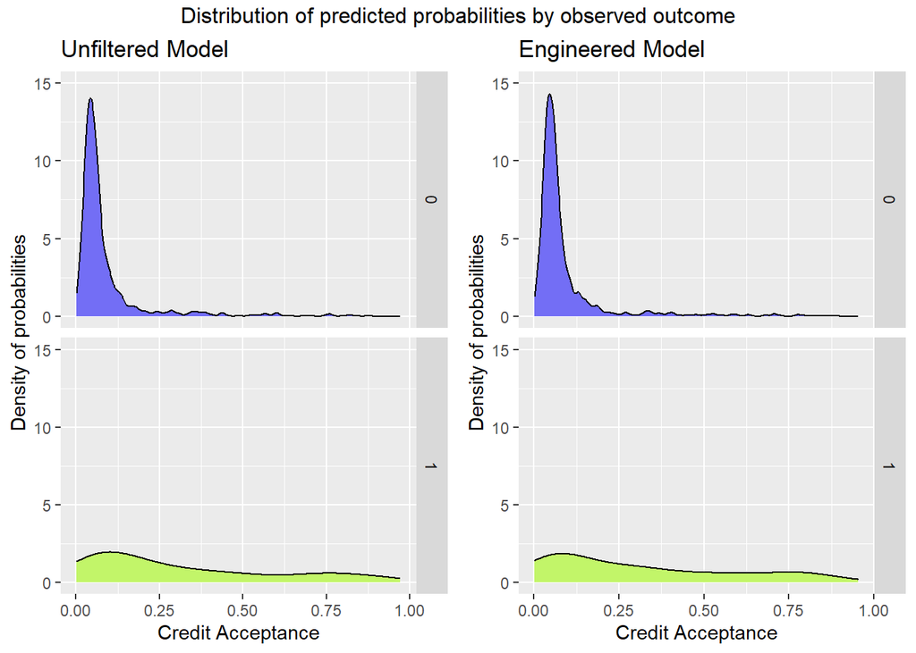

```r
g1 <- ggplot(testProbs, aes(x = Probs, fill = as.factor(Outcome))) +
  geom_density() +
  facet_grid(Outcome ~ .) +
  scale_fill_manual(values = palette3) +
  labs(x = "Credit Acceptance", y = "Density of probabilities",
       title = "Unfiltered Model") +
  scale_y_continuous(limits = c(0,15)) +
  theme(strip.text.x = element_text(size = 18),
        legend.position = "none")

g2 <- ggplot(testProbs_extra, aes(x = Probs, fill = as.factor(Outcome))) +
  geom_density() +
  facet_grid(Outcome ~ .) +
  scale_fill_manual(values = palette3) +
  labs(x = "Credit Acceptance", y = "Density of probabilities",
       title = "Engineered Model") +
  scale_y_continuous(limits = c(0,15)) +
  theme(strip.text.x = element_text(size = 18),
        legend.position = "none")

grid.arrange(g1, g2, ncol = 2, top = "Distribution of predicted probabilities by observed outcome")
```

Both models predict far more negative outcomes than positive, which mimics the data set. The engineered model has a slightly higher concentration of predictions below 0.2. The engineered model and the unfiltered model appear to predict very similarly for positive outcomes.

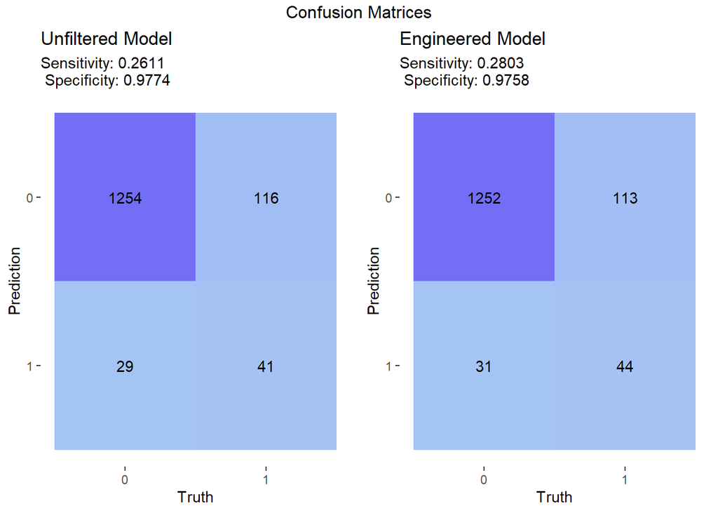

```r
c1 <- caret::confusionMatrix(testProbs$predOutcome, testProbs$Outcome,
                       positive = "1")

c1_sens <- round(c1[4][[1]][1], 4)
c1_spec <- round(c1[4][[1]][2], 4)

cm1 <- yardstick::conf_mat(testProbs, Outcome, predOutcome)

au1 <- autoplot(cm1, type = "heatmap") +
  scale_fill_gradient(low=palette3[3],high = palette3[1])+
  labs(title = "Unfiltered Model", subtitle= paste0("Sensitivity: ", toString(c1_sens), " \n Specificity: ", toString(c1_spec)))


c2 <- caret::confusionMatrix(testProbs_extra$predOutcome, testProbs_extra$Outcome,
                       positive = "1")

c2_sens <- round(c2[4][[1]][1], 4)
c2_spec <- round(c2[4][[1]][2], 4)

cm2 <- yardstick::conf_mat(testProbs_extra, Outcome, predOutcome)

au2 <- autoplot(cm2, type = "heatmap") +
  scale_fill_gradient(low=palette3[3],high = palette3[1])+
  labs(title = "Engineered Model", subtitle= paste0("Sensitivity: ", toString(c2_sens), " \n Specificity: ", toString(c2_spec)))

grid.arrange(au1, au2, top = "Confusion Matrices", ncol = 2)
```

A majority of predictions by both models are true negatives, but the engineered model predicts two less true negatives and three more true positives than the unfiltered model. The engineered model also has improved sensitivity but worse specificity, though the change is minimal, especially for specificity.

```r
# engineered model
ctrl <- trainControl(method = "cv", number = 100, classProbs=TRUE, summaryFunction=twoClassSummary)

housingsubs_extra$y <- fct_relevel(housingsubs_extra$y, "yes")

cvFit <- train(relevel(y, ref = "yes") ~ .,
                  data=housingsubs_extra %>%
                    dplyr::select(-y_numeric),
                method="glm", family="binomial",
                metric="ROC", trControl = ctrl)
```

```r
housingsubs$y <- fct_relevel(housingsubs$y, "yes")

cvFit2 <- train(relevel(y, ref = "yes") ~ .,
                  data=housingsubs %>%
                    dplyr::select(-y_numeric),
                method="glm", family="binomial",
                metric="ROC", trControl = ctrl)
```

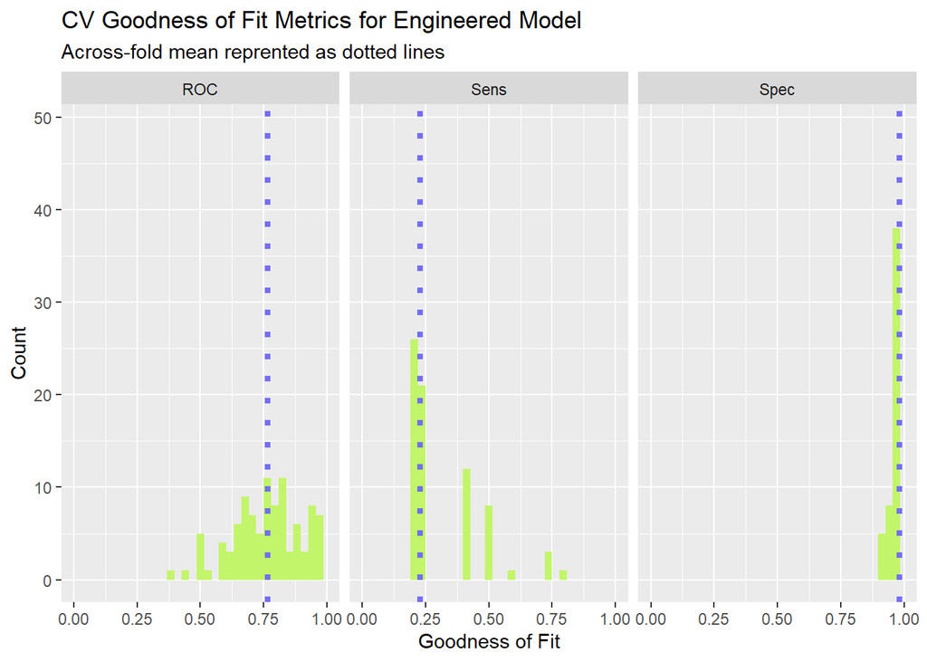

```r
dplyr::select(cvFit$resample, -Resample) %>%
  gather(metric, value) %>%
  left_join(gather(cvFit$results[2:4], metric, mean)) %>%
  ggplot(aes(value)) +
    geom_histogram(bins=35, fill = palette3[2]) +
    facet_wrap(~metric) +
    geom_vline(aes(xintercept = mean), colour = palette3[1], linetype = 3, size = 1.5) +
    scale_x_continuous(limits = c(0, 1)) +
    labs(x="Goodness of Fit", y="Count", title="CV Goodness of Fit Metrics for Engineered Model",
         subtitle = "Across-fold mean reprented as dotted lines") + theme_gray()
```

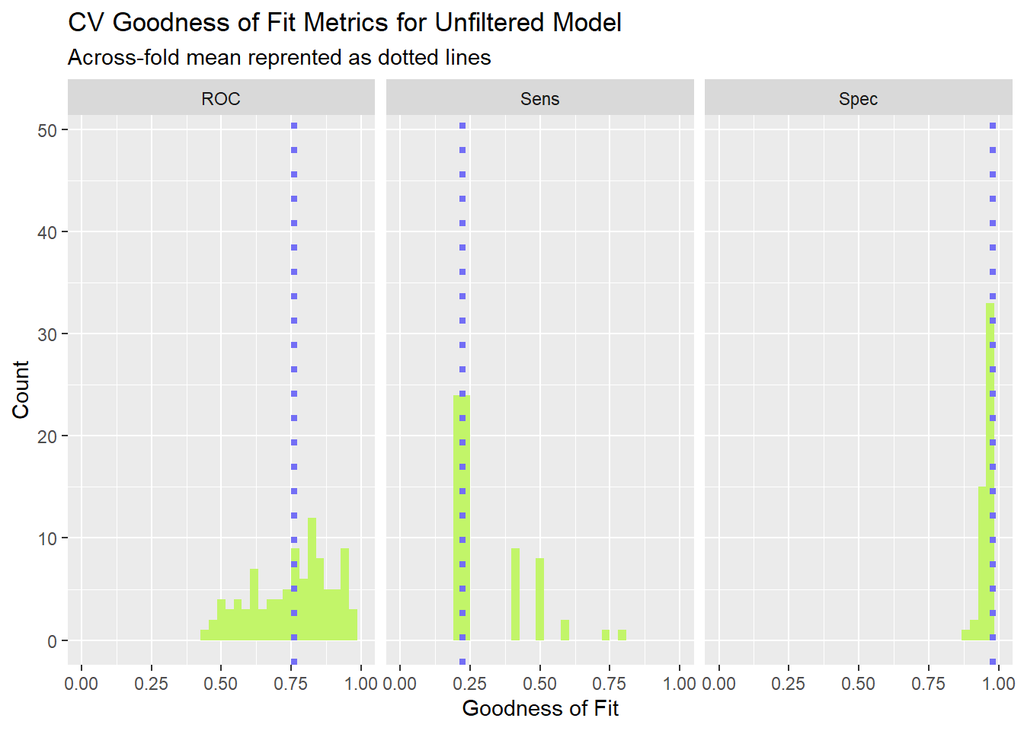

```r
dplyr::select(cvFit2$resample, -Resample) %>%
  gather(metric, value) %>%
  left_join(gather(cvFit2$results[2:4], metric, mean)) %>%
  ggplot(aes(value)) +
    geom_histogram(bins=35, fill = palette3[2]) +
    facet_wrap(~metric) +
    geom_vline(aes(xintercept = mean), colour = palette3[1], linetype = 3, size = 1.5) +
    scale_x_continuous(limits = c(0, 1)) +
    labs(x="Goodness of Fit", y="Count", title="CV Goodness of Fit Metrics for Unfiltered Model",
         subtitle = "Across-fold mean reprented as dotted lines") + theme_gray()
```

Though the models appeared to perform slightly differently when looking at the outcomes against one training set, the cross validation shows that model performance is almost indistinguishable between the engineered and unfiltered models. The engineered model has a slightly higher sensitivity and a slightly higher ROC than the unfiltered model. On both of these measures, the engineered model performs better, though there is not a noticeble change in specificity. Both models have an ROC of around 0.75 indicating that the models are more useful than random, but not immensely so.

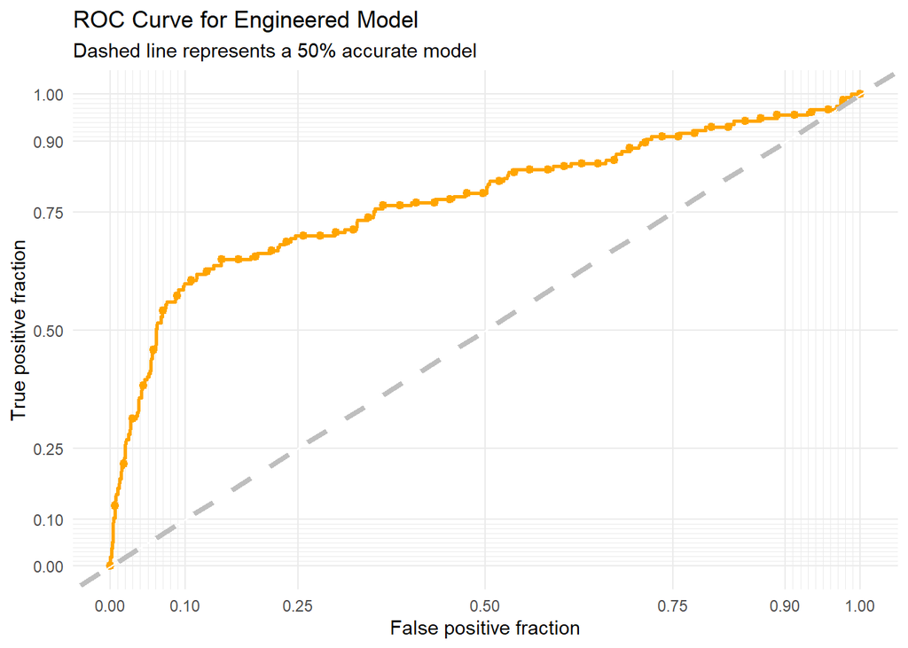

```r
ggplot(testProbs_extra, aes(d = as.numeric(Outcome), m = Probs)) +
  geom_roc(n.cuts = 50, labels = FALSE, colour = palette3[4]) +
  style_roc(theme = theme_grey) +
  geom_abline(slope = 1, intercept = 0, size = 1.5, color = 'grey', linetype = "dashed") +
  labs(title = "ROC Curve for Engineered Model", subtitle= "Dashed line represents a 50% accurate model") + theme_minimal()
```

The ROC curve shows that the engineered model has some predictive usefulness because it is above the dashed line, which represents the results a coin flip model would produce. However, the model does not extend very far above the dashed line, indicating a limited usefulness in prediction. This also means that the model is not in danger of being overfitted, so even with a limited accuracy the model is likely to still be generalizable.

### Maximizing Revenues

The following values were used to conduct the cost- benefit analysis: - 2% property tax rate in Emil - Houses last 60-70 years on average, so it was assumed that the average house would have 30 years remaining - Homeowners who used the tax credit saw a $10,000 increase in property value - Neighbors to residents who used the tax credit saw an aggregate $56,000 property value increase - Reaching out to a homeowner costs $2,850 - The value of the tax credit is $5,000 - 25% of contacted eligible residents accept the tax credit

Therefore, the cost of:

```r
cost_benefit_table <-
   testProbs_extra %>%
      count(predOutcome, Outcome) %>%
      summarize(True_Negative = sum(n[predOutcome==0 & Outcome==0]),
                True_Positive = sum(n[predOutcome==1 & Outcome==1]),
                False_Negative = sum(n[predOutcome==0 & Outcome==1]),
                False_Positive = sum(n[predOutcome==1 & Outcome==0])) %>%
       gather(Variable, Count) %>%
       mutate(Revenue =
               ifelse(Variable == "True_Negative", Count * 0,
               ifelse(Variable == "True_Positive", (-2850 + (-5000 + 30 * (66000 * 0.02)) * (Count * 0.25)),
               ifelse(Variable == "False_Negative", Count * 0,
               ifelse(Variable == "False_Positive", (-2850) * Count, 0))))) %>%
    bind_cols(data.frame(Description = c(
              "We correctly predicted no credit acceptance",
              "We correctly predicted credit acceptance",
              "We predicted no credit acceptance and credit was accepted",
              "We predicted credit acceptance and credit was not accepted")))

kable(cost_benefit_table,
       caption = "Cost/Benefit Table") %>% kable_styling()
```

Cost/Benefit Table

| Variable | Count | Revenue | Description |
| --- | --- | --- | --- |
| True_Negative | 1252 | 0 | We correctly predicted no credit acceptance |
| True_Positive | 44 | 377750 | We correctly predicted credit acceptance |
| False_Negative | 113 | 0 | We predicted no credit acceptance and credit was accepted |
| False_Positive | 31 | -88350 | We predicted credit acceptance and credit was not accepted |

```r
iterateThresholds <- function(data) {
  x = .01
  all_prediction <- data.frame()
  while (x <= 1) {

  this_prediction <-
      data %>%
      mutate(predOutcome = ifelse(Probs > x, 1, 0)) %>%
      count(predOutcome, Outcome) %>%
      summarize(True_Negative = sum(n[predOutcome==0 & Outcome==0]),
                True_Positive = sum(n[predOutcome==1 & Outcome==1]),
                False_Negative = sum(n[predOutcome==0 & Outcome==1]),
                False_Positive = sum(n[predOutcome==1 & Outcome==0])) %>%
     gather(Variable, Count) %>%
     mutate(Revenue =
               ifelse(Variable == "True_Negative", Count * 0,
               ifelse(Variable == "True_Positive", (-2850 + (-5000 + 30 * (66000 * 0.02)) * (Count * 0.25)),
               ifelse(Variable == "False_Negative", Count * 0,
               ifelse(Variable == "False_Positive", (-2850) * Count, 0)))),
            Threshold = x)

  all_prediction <- rbind(all_prediction, this_prediction)
  x <- x + .01
  }
return(all_prediction)
}
```

```r
whichThreshold <- iterateThresholds(testProbs_extra)
```

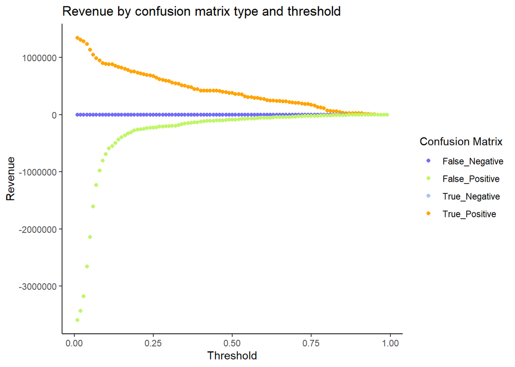

```r
whichThreshold %>%
  ggplot(.,aes(Threshold, Revenue, colour = Variable)) +
  geom_point() +
  scale_colour_manual(values = palette3) +
  labs(title = "Revenue by confusion matrix type and threshold",
       y = "Revenue") +
  theme_classic() +
  guides(colour=guide_legend(title = "Confusion Matrix"))
```

As the threshold increases, the revenues from all aspects of the confusion matrix approach zero. The maximum revenue would be at a threshold of around 0.2 because this is where the True Positive revenue exceeds the negative revenue from False Positives by the largest margin.

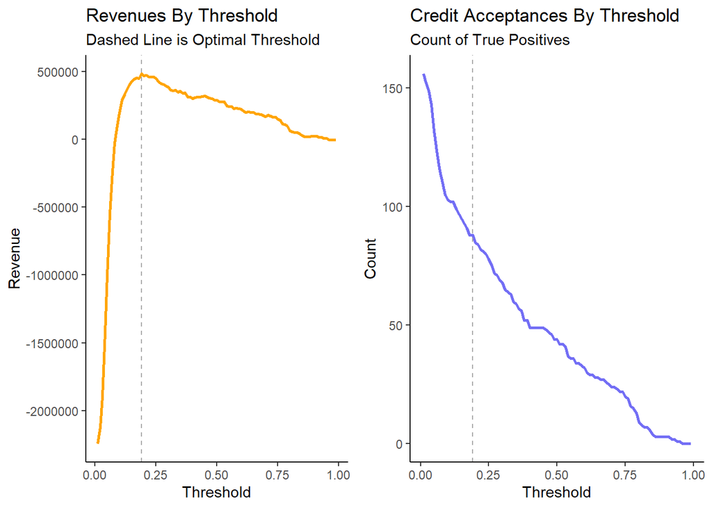

```r
whichThreshold_revenue <-
whichThreshold %>%
    group_by(Threshold) %>%
    summarize(Revenue = sum(Revenue))

whichThreshold_count <-
whichThreshold %>%
  filter(Variable == "True_Positive") %>%
    group_by(Threshold) %>%
    summarize(Count = sum(Count))

p1 <- ggplot(whichThreshold_revenue)+
  geom_line(aes(x = Threshold, y = Revenue), color = palette3[4], lwd = 1)+
  geom_vline(xintercept =  pull(arrange(whichThreshold_revenue, -Revenue)[1,1]), color = "darkgray", linetype="dashed")+
    labs(title = "Revenues By Threshold",
         subtitle = "Dashed Line is Optimal Threshold")+
  theme_classic()

p2 <- ggplot(whichThreshold_count)+
  geom_line(aes(x = Threshold, y = Count), color = palette3[1], lwd = 1)+
  geom_vline(xintercept =  pull(arrange(whichThreshold_revenue, -Revenue)[1,1]), color = "darkgray", linetype="dashed") +
    labs(title = "Credit Acceptances By Threshold",
         subtitle = "Count of True Positives")+
  theme_classic()

grid.arrange(p1, p2, ncol = 2)
```

Based on revenue, the optimal threshold for this model to label a resident as likely to participate is 19%. Up until that point the revenue is rapidly increasing as the threshold raises, but after 19% the revenue begins slowly trending downward. As expected, the number of true positive credit acceptances decreases as the threshold to be considered positive increases. At the threshold of 19%, there are 88 acceptances, which is less than a quarter of the number of residents who accepted the credit in the original data set.

```r
# optimal threshold is 0.19

pred_table_50 <- testProbs_extra %>%
  count(predOutcome, Outcome) %>%
      summarize(True_Negative = sum(n[predOutcome==0 & Outcome==0]),
                True_Positive = sum(n[predOutcome==1 & Outcome==1]),
                False_Negative = sum(n[predOutcome==0 & Outcome==1]),
                False_Positive = sum(n[predOutcome==1 & Outcome==0])) %>%
       gather(Variable, Count) %>%
       mutate(Revenue =
               ifelse(Variable == "True_Negative", Count * 0,
               ifelse(Variable == "True_Positive", (-2850 + (-5000 + 30 * (66000 * 0.02)) * (Count * 0.25)),
               ifelse(Variable == "False_Negative", Count * 0,
               ifelse(Variable == "False_Positive", (-2850) * Count, 0))))) %>%
  mutate(
    Total_Count_of_Credits = if_else(Variable == "True_Positive", Count, 0)
  ) %>%
  summarize(
    Revenue = sum(Revenue),
    Total_Count_of_Credits = sum(Total_Count_of_Credits)
  ) %>%
  mutate(Model = "50 % Threshold",
         Revenue = currency(Revenue, digits = 0L)) %>%
  dplyr::select(Model, Revenue, Total_Count_of_Credits)

pred_table_20 <- testProbs_extra %>%
  mutate(
    predOutcome = if_else(Probs > pull(arrange(whichThreshold_revenue, -Revenue)[1,1]), 1, 0)
  ) %>%
  count(predOutcome, Outcome) %>%
      summarize(True_Negative = sum(n[predOutcome==0 & Outcome==0]),
                True_Positive = sum(n[predOutcome==1 & Outcome==1]),
                False_Negative = sum(n[predOutcome==0 & Outcome==1]),
                False_Positive = sum(n[predOutcome==1 & Outcome==0])) %>%
       gather(Variable, Count) %>%
       mutate(Revenue =
               ifelse(Variable == "True_Negative", Count * 0,
               ifelse(Variable == "True_Positive", (-2850 + (-5000 + 30 * (66000 * 0.02)) * (Count * 0.25)),
               ifelse(Variable == "False_Negative", Count * 0,
               ifelse(Variable == "False_Positive", (-2850) * Count, 0))))) %>%
  mutate(
    Total_Count_of_Credits = if_else(Variable == "True_Positive", Count, 0)
  ) %>%
  summarize(
    Revenue = sum(Revenue),
    Total_Count_of_Credits = sum(Total_Count_of_Credits)
  ) %>%
  mutate(Model = "19 % Threshold",
         Revenue = currency(Revenue, digits = 0L)) %>%
  dplyr::select(Model, Revenue, Total_Count_of_Credits)

threshold_table <- rbind(pred_table_20, pred_table_50)

kable(threshold_table,
       caption = "Thresholds By Revenues and Counts") %>% kable_styling()
```

Thresholds By Revenues and Counts

| Model | Revenue | Total_Count_of_Credits |
| --- | --- | --- |
| 19 % Threshold | $481,900 | 88 |
| 50 % Threshold | $289,400 | 44 |

Lowering the threshold from 50% to 19% would allow the city generate almost an additional $200,000 and double the number of participants.

## Conclusion

This model is not incredibly accurate, as demonstrated by the lower ROC scores around 0.75, nor is it very sensitive, as its true positive rate barely exceeds 0.25. However, considering the current process being used by the city is random, this model has proven to be more accurate than the current methods. Additionally, the implementation of this model has the potential to generate more than $481,000 in revenue for the city. With the proper time and resources, ideally the model would be improved before implementation, especially to raise the sensitivity rate. More data could potentially be useful here, especially data with more residents enrolling in the program. Additionally, a clearer picture of what each of the levels mean in some categorical variables like `education` or `job` could allow for more adept feature engineering.

However, though the model is not perfect, because the city is presumably losing money every year by advertising randomly to eligible homeowners, implementing this model is likely more useful than the current state of operation. Implementing this model would entail gathering the relevant data on eligible homeowners, then allowing the algorithm to predict how likely they are to participate in the program. If the model predicts a likelihood above 19%, the city should send marketing materials to that individual. The individuals suggested by the model are more likely to accept the tax credit, but members of HCD should still remain diligent in following up with those homeowners.